# ● Load and explore data

## 1. Import the required libraries and read the dataset.

```python
# Importing the required libraries.
import numpy as np
import pandas as pd
import matplotlib.pyplot as plt
import seaborn as sns

import warnings
warnings.filterwarnings('ignore')
```

```python
# Load the dataset.
df = pd.read_csv("fifa.csv")
```

```python
# Load the dataset variable information.
df_var =pd.read_csv("fifa_ variable_information.csv")
```

## 2. Check the first few samples, shape, info of the data and try to familiarize yourself with different features.

```python
# Display the dataset variable information.
df_var
```

|  | ID | unique id for every player |
| --- | --- | --- |
| 0 | Name | name |
| 1 | Age | age |
| 2 | Photo | url to the player's photo |
| 3 | Nationality | nationality |
| 4 | Flag | url to players's country flag |
| 5 | Overall | overall rating |
| 6 | Potential | potential rating |
| 7 | Club | current club |
| 8 | Club Logo | url to club logo |
| 9 | Value | current market value |
| 10 | Wage | current wage |
| 11 | Preferred Foot | left/right |
| 12 | International Reputation | rating on scale of 5 |
| 13 | Weak Foot | rating on scale of 5 |
| 14 | Skill Moves | rating on scale of 5 |
| 15 | Work Rate | attack work rate/defence work rate |
| 16 | Body Type | body type of player |
| 17 | Position | position on the pitch |
| 18 | Jersey Number | jersey number |
| 19 | Joined | joined date |
| 20 | Loaned From | club name if applicable |
| 21 | Contract Valid Until | contract end date |
| 22 | Height | height of the player |
| 23 | Weight | weight of the player |
| 24 | Crossing | rating on scale of 100 |
| 25 | Finishing | rating on scale of 100 |
| 26 | HeadingAccuracy | rating on scale of 100 |
| 27 | ShortPassing | rating on scale of 100 |
| 28 | Volleys | rating on scale of 100 |
| 29 | Dribbling | rating on scale of 100 |
| 30 | Curve | rating on scale of 100 |
| 31 | FKAccuracy | rating on scale of 100 |
| 32 | LongPassing | rating on scale of 100 |
| 33 | BallControl | rating on scale of 100 |
| 34 | Acceleration | rating on scale of 100 |
| 35 | SprintSpeed | rating on scale of 100 |
| 36 | Agility | rating on scale of 100 |
| 37 | Reactions | rating on scale of 100\ |
| 38 | Balance | rating on scale of 100 |
| 39 | ShotPower | rating on scale of 100 |
| 40 | Jumping | rating on scale of 100 |
| 41 | Stamina | rating on scale of 100 |
| 42 | Strength | rating on scale of 100 |
| 43 | LongShots | rating on scale of 100 |
| 44 | Aggression | rating on scale of 100 |
| 45 | Interceptions | rating on scale of 100 |
| 46 | Positioning | rating on scale of 100 |
| 47 | Vision | rating on scale of 100 |
| 48 | Penalties | rating on scale of 100 |
| 49 | Composure | rating on scale of 100 |
| 50 | Marking | rating on scale of 100 |
| 51 | StandingTackle | rating on scale of 100 |
| 52 | SlidingTackle | rating on scale of 100 |
| 53 | GKDiving | rating on scale of 100 |
| 54 | GKHandling | rating on scale of 100 |
| 55 | GKKicking | rating on scale of 100 |
| 56 | GKPositioning | rating on scale of 100 |
| 57 | GKReflexes | rating on scale of 100 |
| 58 | Release Clause | release clause value |

```python
# Display the first five samples.
df.head()
```

|  | ID | Name | Age | Photo | Nationality | Flag | Overall | Potential | Club | Club Logo | ... | Composure | Marking | StandingTackle | SlidingTackle | GKDiving | GKHandling | GKKicking | GKPositioning | GKReflexes | Release Clause |
| --- | --- | --- | --- | --- | --- | --- | --- | --- | --- | --- | --- | --- | --- | --- | --- | --- | --- | --- | --- | --- | --- |
| 0 | 158023 | L. Messi | 31 | https://cdn.sofifa.org/players/4/19/158023.png | Argentina | https://cdn.sofifa.org/flags/52.png | 94 | 94 | FC Barcelona | https://cdn.sofifa.org/teams/2/light/241.png | ... | 96.0 | 33.0 | 28.0 | 26.0 | 6.0 | 11.0 | 15.0 | 14.0 | 8.0 | €226.5M |
| 1 | 20801 | Cristiano Ronaldo | 33 | https://cdn.sofifa.org/players/4/19/20801.png | Portugal | https://cdn.sofifa.org/flags/38.png | 94 | 94 | Juventus | https://cdn.sofifa.org/teams/2/light/45.png | ... | 95.0 | 28.0 | 31.0 | 23.0 | 7.0 | 11.0 | 15.0 | 14.0 | 11.0 | €127.1M |
| 2 | 190871 | Neymar Jr | 26 | https://cdn.sofifa.org/players/4/19/190871.png | Brazil | https://cdn.sofifa.org/flags/54.png | 92 | 93 | Paris Saint-Germain | https://cdn.sofifa.org/teams/2/light/73.png | ... | 94.0 | 27.0 | 24.0 | 33.0 | 9.0 | 9.0 | 15.0 | 15.0 | 11.0 | €228.1M |
| 3 | 193080 | De Gea | 27 | https://cdn.sofifa.org/players/4/19/193080.png | Spain | https://cdn.sofifa.org/flags/45.png | 91 | 93 | Manchester United | https://cdn.sofifa.org/teams/2/light/11.png | ... | 68.0 | 15.0 | 21.0 | 13.0 | 90.0 | 85.0 | 87.0 | 88.0 | 94.0 | €138.6M |
| 4 | 192985 | K. De Bruyne | 27 | https://cdn.sofifa.org/players/4/19/192985.png | Belgium | https://cdn.sofifa.org/flags/7.png | 91 | 92 | Manchester City | https://cdn.sofifa.org/teams/2/light/10.png | ... | 88.0 | 68.0 | 58.0 | 51.0 | 15.0 | 13.0 | 5.0 | 10.0 | 13.0 | €196.4M |

5 rows × 60 columns

```python
# Check the shape of the dataset.
df.shape
```

```
(18207, 60)
```

```python
# Display info of the dataset.
df.info()
```

```
<class 'pandas.core.frame.DataFrame'>
RangeIndex: 18207 entries, 0 to 18206
Data columns (total 60 columns):
 #   Column                    Non-Null Count  Dtype
---  ------                    --------------  -----
 0   ID                        18207 non-null  int64
 1   Name                      18207 non-null  object
 2   Age                       18207 non-null  int64
 3   Photo                     18207 non-null  object
 4   Nationality               18207 non-null  object
 5   Flag                      18207 non-null  object
 6   Overall                   18207 non-null  int64
 7   Potential                 18207 non-null  int64
 8   Club                      17966 non-null  object
 9   Club Logo                 18207 non-null  object
```

[output cut: 52 more lines]

## 3. Drop the columns which you think redundant for the analysis.

```python
# Dropping the ID, Photo, Flag and Club Logo columns.
df.drop(['ID', 'Photo', 'Flag', 'Club Logo'], axis=1, inplace=True)
```

```python
# Displaying the first five dataset after dropping the redundant columns.
df.head()
```

|  | Name | Age | Nationality | Overall | Potential | Club | Value | Wage | Preferred Foot | International Reputation | ... | Composure | Marking | StandingTackle | SlidingTackle | GKDiving | GKHandling | GKKicking | GKPositioning | GKReflexes | Release Clause |
| --- | --- | --- | --- | --- | --- | --- | --- | --- | --- | --- | --- | --- | --- | --- | --- | --- | --- | --- | --- | --- | --- |
| 0 | L. Messi | 31 | Argentina | 94 | 94 | FC Barcelona | €110.5M | €565K | Left | 5.0 | ... | 96.0 | 33.0 | 28.0 | 26.0 | 6.0 | 11.0 | 15.0 | 14.0 | 8.0 | €226.5M |
| 1 | Cristiano Ronaldo | 33 | Portugal | 94 | 94 | Juventus | €77M | €405K | Right | 5.0 | ... | 95.0 | 28.0 | 31.0 | 23.0 | 7.0 | 11.0 | 15.0 | 14.0 | 11.0 | €127.1M |
| 2 | Neymar Jr | 26 | Brazil | 92 | 93 | Paris Saint-Germain | €118.5M | €290K | Right | 5.0 | ... | 94.0 | 27.0 | 24.0 | 33.0 | 9.0 | 9.0 | 15.0 | 15.0 | 11.0 | €228.1M |
| 3 | De Gea | 27 | Spain | 91 | 93 | Manchester United | €72M | €260K | Right | 4.0 | ... | 68.0 | 15.0 | 21.0 | 13.0 | 90.0 | 85.0 | 87.0 | 88.0 | 94.0 | €138.6M |
| 4 | K. De Bruyne | 27 | Belgium | 91 | 92 | Manchester City | €102M | €355K | Right | 4.0 | ... | 88.0 | 68.0 | 58.0 | 51.0 | 15.0 | 13.0 | 5.0 | 10.0 | 13.0 | €196.4M |

5 rows × 56 columns

# ● Data Cleaning and Preprocessing

## 4. Convert the columns "Value", "Wage", "Release Clause" to float datatype after getting rid of currency symbol and suffix.

#### - Note: When the record/entry has "M"(indicates millions) as suffix you need to multiply that value with 1000000

#### - When the record/entry has "K"(indicates thousands) as suffix you need to multiply that value with 1000

```python
# Converting "Value" column to float datatype after removing '€' symbol and changing data to numbers based on suffix.
df['Value'] = df['Value'].replace({'€':'', 'K':'*1e3', 'M':'*1e6'}, regex=True).map(pd.eval).astype('float')
```

```python
# Converting "Wage" column to float datatype after removing '€' symbol and changing data to numbers based on suffix.
df['Wage'] = df['Wage'].replace({'€':'', 'K':'*1e3', 'M':'*1e6'}, regex=True).map(pd.eval).astype('float')
```

```python
# Converting "Release Clause" column to float datatype after removing '€' symbol and changing data to numbers based on suffix.
df['Release Clause'] = df['Release Clause'].fillna(0).replace({'€':'', 'K':'*1e3', 'M':'*1e6'}, regex=True).map(pd.eval).astype('float')
```

```python
# Checking datatypes after converting the above columns.
df.info()
```

```
<class 'pandas.core.frame.DataFrame'>
RangeIndex: 18207 entries, 0 to 18206
Data columns (total 56 columns):
 #   Column                    Non-Null Count  Dtype
---  ------                    --------------  -----
 0   Name                      18207 non-null  object
 1   Age                       18207 non-null  int64
 2   Nationality               18207 non-null  object
 3   Overall                   18207 non-null  int64
 4   Potential                 18207 non-null  int64
 5   Club                      17966 non-null  object
 6   Value                     18207 non-null  float64
 7   Wage                      18207 non-null  float64
 8   Preferred Foot            18159 non-null  object
 9   International Reputation  18159 non-null  float64
```

[output cut: 48 more lines]

```python
# Checking the converted data.
df.head()
```

|  | Name | Age | Nationality | Overall | Potential | Club | Value | Wage | Preferred Foot | International Reputation | ... | Composure | Marking | StandingTackle | SlidingTackle | GKDiving | GKHandling | GKKicking | GKPositioning | GKReflexes | Release Clause |
| --- | --- | --- | --- | --- | --- | --- | --- | --- | --- | --- | --- | --- | --- | --- | --- | --- | --- | --- | --- | --- | --- |
| 0 | L. Messi | 31 | Argentina | 94 | 94 | FC Barcelona | 110500000.0 | 565000.0 | Left | 5.0 | ... | 96.0 | 33.0 | 28.0 | 26.0 | 6.0 | 11.0 | 15.0 | 14.0 | 8.0 | 226500000.0 |
| 1 | Cristiano Ronaldo | 33 | Portugal | 94 | 94 | Juventus | 77000000.0 | 405000.0 | Right | 5.0 | ... | 95.0 | 28.0 | 31.0 | 23.0 | 7.0 | 11.0 | 15.0 | 14.0 | 11.0 | 127100000.0 |
| 2 | Neymar Jr | 26 | Brazil | 92 | 93 | Paris Saint-Germain | 118500000.0 | 290000.0 | Right | 5.0 | ... | 94.0 | 27.0 | 24.0 | 33.0 | 9.0 | 9.0 | 15.0 | 15.0 | 11.0 | 228100000.0 |
| 3 | De Gea | 27 | Spain | 91 | 93 | Manchester United | 72000000.0 | 260000.0 | Right | 4.0 | ... | 68.0 | 15.0 | 21.0 | 13.0 | 90.0 | 85.0 | 87.0 | 88.0 | 94.0 | 138600000.0 |
| 4 | K. De Bruyne | 27 | Belgium | 91 | 92 | Manchester City | 102000000.0 | 355000.0 | Right | 4.0 | ... | 88.0 | 68.0 | 58.0 | 51.0 | 15.0 | 13.0 | 5.0 | 10.0 | 13.0 | 196400000.0 |

5 rows × 56 columns

## 5. Convert the column "Joined" into integer data type with keeping only the year.

```python
# Checking the "Joined" columns values.
df['Joined']
```

```
0         Jul 1, 2004
1        Jul 10, 2018
2         Aug 3, 2017
3         Jul 1, 2011
4        Aug 30, 2015
             ...
18202     May 3, 2017
18203    Mar 19, 2018
18204     Jul 1, 2017
18205    Apr 24, 2018
18206    Oct 30, 2018
Name: Joined, Length: 18207, dtype: object
```

```python
# Converting the column "Joined" to integer datatype keeping the year only.
df['Joined'] = pd.DatetimeIndex(df['Joined']).year
df['Joined'] = pd.to_numeric(df['Joined'], errors='coerce').astype(pd.Int64Dtype())
df['Joined']
```

```
0        2004
1        2018
2        2017
3        2011
4        2015
         ...
18202    2017
18203    2018
18204    2017
18205    2018
18206    2018
Name: Joined, Length: 18207, dtype: Int64
```

## 6. Convert the column "Contract Valid Until" to pandas datetime type.

```python
# Converting the column "Contract Valid Until" to pandas datetime type.
df['Contract Valid Until'] = pd.to_datetime(df['Contract Valid Until'])
df['Contract Valid Until']
```

```
0       2021-01-01
1       2022-01-01
2       2022-01-01
3       2020-01-01
4       2023-01-01
           ...
18202   2019-01-01
18203   2020-01-01
18204   2021-01-01
18205   2019-01-01
18206   2019-01-01
Name: Contract Valid Until, Length: 18207, dtype: datetime64[ns]
```

## 7. The column 'Height' is in inches with a quotation mark, Convert to float with decimal points.

```python
df['Height'] = df['Height'].fillna("0'0").apply(lambda x: float(x.split("'")[0])*12+float(x.split("'")[1]))
```

```python
df['Height']
```

```
0        67.0
1        74.0
2        69.0
3        76.0
4        71.0
         ...
18202    69.0
18203    75.0
18204    68.0
18205    70.0
18206    70.0
Name: Height, Length: 18207, dtype: float64
```

## 8. The column "Weight" has the suffix as lbs, remove the suffix and convert to float.

```python
df['Weight'] = df['Weight'].fillna(0).replace({'lbs':''}, regex=True).map(pd.eval).astype('float')
```

```python
df['Weight']
```

```
0        159.0
1        183.0
2        150.0
3        168.0
4        154.0
         ...
18202    134.0
18203    170.0
18204    148.0
18205    154.0
18206    176.0
Name: Weight, Length: 18207, dtype: float64
```

## 9. Check for the percentage of missing values and impute them with appropriate imputation techniques.

```python
# Calculate the percentage of missing values.
df.isnull().sum()/len(df)*100
```

```
Name                         0.000000
Age                          0.000000
Nationality                  0.000000
Overall                      0.000000
Potential                    0.000000
Club                         1.323667
Value                        0.000000
Wage                         0.000000
Preferred Foot               0.263635
International Reputation     0.263635
Weak Foot                    0.263635
Skill Moves                  0.263635
Work Rate                    0.263635
Body Type                    0.263635
Position                     0.329544
Jersey Number                0.329544
Joined                       8.529686
Loaned From                 93.057615
Contract Valid Until         1.587302
Height                       0.000000
Weight                       0.000000
Crossing                     0.263635
Finishing                    0.263635
HeadingAccuracy              0.263635
ShortPassing                 0.263635
Volleys                      0.263635
Dribbling                    0.263635
Curve                        0.263635
FKAccuracy                   0.263635
LongPassing                  0.263635
BallControl                  0.263635
Acceleration                 0.263635
SprintSpeed                  0.263635
Agility                      0.263635
Reactions                    0.263635
Balance                      0.263635
ShotPower                    0.263635
Jumping                      0.263635
Stamina                      0.263635
Strength                     0.263635
LongShots                    0.263635
Aggression                   0.263635
Interceptions                0.263635
Positioning                  0.263635
Vision                       0.263635
Penalties                    0.263635
Composure                    0.263635
Marking                      0.263635
StandingTackle               0.263635
SlidingTackle                0.263635
GKDiving                     0.263635
GKHandling                   0.263635
GKKicking                    0.263635
GKPositioning                0.263635
GKReflexes                   0.263635
Release Clause               0.000000
dtype: float64
```

```python
# Dropping Column "Loaned From" as 93% values are missing
df.drop(['Loaned From'],axis=1, inplace=True)
```

```python
df['Joined'].fillna(df['Joined'].median(), inplace=True)
```

# ● Exploratory Data Analysis

## 10. Plot the distribution of Overall rating for all the players and write your findings.

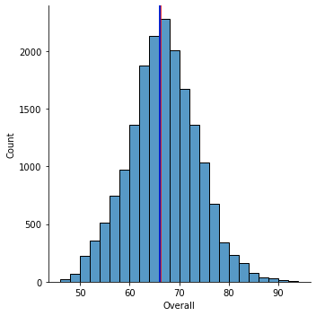

```
Mean:  66.23869940132916
Median:  66.0
Mode:  66
```

```python
sns.displot(df['Overall'], binwidth=2)
plt.axvline(df['Overall'].mean(), color='red')
plt.axvline(df['Overall'].median(), color='green')
plt.axvline(df['Overall'].mode().values[0], color='blue')
plt.show()

print("Mean: ", df['Overall'].mean())
print("Median: ", df['Overall'].median())
print("Mode: ", df['Overall'].mode().values[0])
```

## 11. Retrieve the names of top20 players based on the Overall rating.

```python
top_20_names = df.sort_values(by="Overall", axis=0, ascending=False).head(20)
top_20_names['Name']
```

```
0              L. Messi
1     Cristiano Ronaldo
2             Neymar Jr
3                De Gea
4          K. De Bruyne
5             E. Hazard
6             L. Modrić
7             L. Suárez
8          Sergio Ramos
12             D. Godín
13          David Silva
9              J. Oblak
11             T. Kroos
10       R. Lewandowski
20      Sergio Busquets
24         G. Chiellini
23            S. Agüero
22             M. Neuer
21            E. Cavani
16              H. Kane
Name: Name, dtype: object
```

## 12. Generate a dataframe which should include all the information of the Top 20 players based on the Overall rating.

```python
top_20_players = df.sort_values(by="Overall", axis=0, ascending=False).head(20)
top_20_players
```

|  | Name | Age | Nationality | Overall | Potential | Club | Value | Wage | Preferred Foot | International Reputation | ... | Composure | Marking | StandingTackle | SlidingTackle | GKDiving | GKHandling | GKKicking | GKPositioning | GKReflexes | Release Clause |
| --- | --- | --- | --- | --- | --- | --- | --- | --- | --- | --- | --- | --- | --- | --- | --- | --- | --- | --- | --- | --- | --- |
| 0 | L. Messi | 31 | Argentina | 94 | 94 | FC Barcelona | 110500000.0 | 565000.0 | Left | 5.0 | ... | 96.0 | 33.0 | 28.0 | 26.0 | 6.0 | 11.0 | 15.0 | 14.0 | 8.0 | 226500000.0 |
| 1 | Cristiano Ronaldo | 33 | Portugal | 94 | 94 | Juventus | 77000000.0 | 405000.0 | Right | 5.0 | ... | 95.0 | 28.0 | 31.0 | 23.0 | 7.0 | 11.0 | 15.0 | 14.0 | 11.0 | 127100000.0 |
| 2 | Neymar Jr | 26 | Brazil | 92 | 93 | Paris Saint-Germain | 118500000.0 | 290000.0 | Right | 5.0 | ... | 94.0 | 27.0 | 24.0 | 33.0 | 9.0 | 9.0 | 15.0 | 15.0 | 11.0 | 228100000.0 |
| 3 | De Gea | 27 | Spain | 91 | 93 | Manchester United | 72000000.0 | 260000.0 | Right | 4.0 | ... | 68.0 | 15.0 | 21.0 | 13.0 | 90.0 | 85.0 | 87.0 | 88.0 | 94.0 | 138600000.0 |
| 4 | K. De Bruyne | 27 | Belgium | 91 | 92 | Manchester City | 102000000.0 | 355000.0 | Right | 4.0 | ... | 88.0 | 68.0 | 58.0 | 51.0 | 15.0 | 13.0 | 5.0 | 10.0 | 13.0 | 196400000.0 |
| 5 | E. Hazard | 27 | Belgium | 91 | 91 | Chelsea | 93000000.0 | 340000.0 | Right | 4.0 | ... | 91.0 | 34.0 | 27.0 | 22.0 | 11.0 | 12.0 | 6.0 | 8.0 | 8.0 | 172100000.0 |
| 6 | L. Modrić | 32 | Croatia | 91 | 91 | Real Madrid | 67000000.0 | 420000.0 | Right | 4.0 | ... | 84.0 | 60.0 | 76.0 | 73.0 | 13.0 | 9.0 | 7.0 | 14.0 | 9.0 | 137400000.0 |
| 7 | L. Suárez | 31 | Uruguay | 91 | 91 | FC Barcelona | 80000000.0 | 455000.0 | Right | 5.0 | ... | 85.0 | 62.0 | 45.0 | 38.0 | 27.0 | 25.0 | 31.0 | 33.0 | 37.0 | 164000000.0 |
| 8 | Sergio Ramos | 32 | Spain | 91 | 91 | Real Madrid | 51000000.0 | 380000.0 | Right | 4.0 | ... | 82.0 | 87.0 | 92.0 | 91.0 | 11.0 | 8.0 | 9.0 | 7.0 | 11.0 | 104600000.0 |
| 12 | D. Godín | 32 | Uruguay | 90 | 90 | Atlético Madrid | 44000000.0 | 125000.0 | Right | 3.0 | ... | 82.0 | 90.0 | 89.0 | 89.0 | 6.0 | 8.0 | 15.0 | 5.0 | 15.0 | 90200000.0 |
| 13 | David Silva | 32 | Spain | 90 | 90 | Manchester City | 60000000.0 | 285000.0 | Left | 4.0 | ... | 93.0 | 59.0 | 53.0 | 29.0 | 6.0 | 15.0 | 7.0 | 6.0 | 12.0 | 111000000.0 |
| 9 | J. Oblak | 25 | Slovenia | 90 | 93 | Atlético Madrid | 68000000.0 | 94000.0 | Right | 3.0 | ... | 70.0 | 27.0 | 12.0 | 18.0 | 86.0 | 92.0 | 78.0 | 88.0 | 89.0 | 144500000.0 |
| 11 | T. Kroos | 28 | Germany | 90 | 90 | Real Madrid | 76500000.0 | 355000.0 | Right | 4.0 | ... | 85.0 | 72.0 | 79.0 | 69.0 | 10.0 | 11.0 | 13.0 | 7.0 | 10.0 | 156800000.0 |
| 10 | R. Lewandowski | 29 | Poland | 90 | 90 | FC Bayern München | 77000000.0 | 205000.0 | Right | 4.0 | ... | 86.0 | 34.0 | 42.0 | 19.0 | 15.0 | 6.0 | 12.0 | 8.0 | 10.0 | 127100000.0 |
| 20 | Sergio Busquets | 29 | Spain | 89 | 89 | FC Barcelona | 51500000.0 | 315000.0 | Right | 4.0 | ... | 90.0 | 90.0 | 86.0 | 80.0 | 5.0 | 8.0 | 13.0 | 9.0 | 13.0 | 105600000.0 |
| 24 | G. Chiellini | 33 | Italy | 89 | 89 | Juventus | 27000000.0 | 215000.0 | Left | 4.0 | ... | 84.0 | 93.0 | 93.0 | 90.0 | 3.0 | 3.0 | 2.0 | 4.0 | 3.0 | 44600000.0 |
| 23 | S. Agüero | 30 | Argentina | 89 | 89 | Manchester City | 64500000.0 | 300000.0 | Right | 4.0 | ... | 90.0 | 30.0 | 20.0 | 12.0 | 13.0 | 15.0 | 6.0 | 11.0 | 14.0 | 119300000.0 |
| 22 | M. Neuer | 32 | Germany | 89 | 89 | FC Bayern München | 38000000.0 | 130000.0 | Right | 5.0 | ... | 70.0 | 17.0 | 10.0 | 11.0 | 90.0 | 86.0 | 91.0 | 87.0 | 87.0 | 62700000.0 |
| 21 | E. Cavani | 31 | Uruguay | 89 | 89 | Paris Saint-Germain | 60000000.0 | 200000.0 | Right | 4.0 | ... | 82.0 | 52.0 | 45.0 | 39.0 | 12.0 | 5.0 | 13.0 | 13.0 | 10.0 | 111000000.0 |
| 16 | H. Kane | 24 | England | 89 | 91 | Tottenham Hotspur | 83500000.0 | 205000.0 | Right | 3.0 | ... | 89.0 | 56.0 | 36.0 | 38.0 | 8.0 | 10.0 | 11.0 | 14.0 | 11.0 | 160700000.0 |

20 rows × 55 columns

## 13. What is the average "Age" and "Wage" of these top 20 players? (use the data frame created in the question 11)

```python
avg_age = top_20_names['Age'].mean()
avg_wage = top_20_names['Wage'].mean()

print("Average age of top 20 players is ", avg_age, " years")
print("Average wage of top 20 players is €", avg_wage)
```

```
Average age of top 20 players is  29.55  years
Average wage of top 20 players is € 294950.0
```

## 14. Among the top 20 players based on the Overall rating, which player has the highest wage? Display the name of the player with his wage.

```python
max_wage = top_20_players.sort_values(by="Wage", axis=0, ascending=False).head(1)
max_wage[['Name', 'Wage']]
```

|  | Name | Wage |
| --- | --- | --- |
| 0 | L. Messi | 565000.0 |

## 15. Generate a dataframe which should include the "Player name", "Club Name", "Wage", and 'Overall rating'.

### - i) find the average Overall rating for each club.

### - ii) Display the average overall rating of Top10 Clubs using a plot

```python
# Creating the dataframe with "Player name", "Club Name", "Wage", and "Overall rating" columns
df_clubs = df[['Name', 'Club', 'Wage', 'Overall']]
df_clubs.head()
```

|  | Name | Club | Wage | Overall |
| --- | --- | --- | --- | --- |
| 0 | L. Messi | FC Barcelona | 565000.0 | 94 |
| 1 | Cristiano Ronaldo | Juventus | 405000.0 | 94 |
| 2 | Neymar Jr | Paris Saint-Germain | 290000.0 | 92 |
| 3 | De Gea | Manchester United | 260000.0 | 91 |
| 4 | K. De Bruyne | Manchester City | 355000.0 | 91 |

```python
# Calculating the average rating for each club
df_clubs_average_rating = df_clubs.groupby('Club')['Overall'].mean()
df_clubs_average_rating
```

```
Club
 SSV Jahn Regensburg     65.586207
1. FC Heidenheim 1846    65.750000
1. FC Kaiserslautern     63.384615
1. FC Köln               70.785714
1. FC Magdeburg          65.615385
                           ...
Zagłębie Sosnowiec       60.760000
Çaykur Rizespor          66.900000
Örebro SK                60.481481
Östersunds FK            63.545455
Śląsk Wrocław            62.200000
Name: Overall, Length: 651, dtype: float64
```

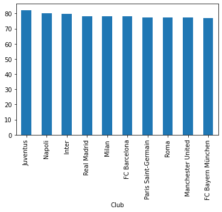

```python
#Displaying the average overall rating for Top 10 clubs
df_clubs_average_rating.sort_values(ascending=False).head(10).plot(kind='bar')
plt.show()
```

## 16. What is the relationship between age and individual potential of the player? Visualize the relationship with appropriate plot and Comment on the same.

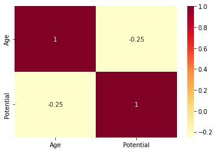

```python
sns.heatmap(df[['Age','Potential']].corr(), cmap='YlOrRd', annot=True)
```

#### There is a negative relation between the player age and potential and as the age increases the player potential decreases.

## 17. Which features directly contribute to the wages of the players? Support your answer with a plot and a metric.

### (hint: use potential, Overall, value, international reputation, and Release Clause)

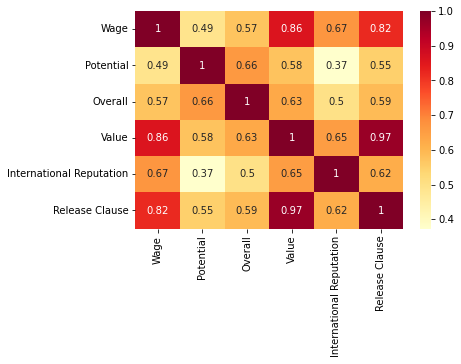

```python
columns = ['Wage', 'Potential', 'Overall', 'Value', 'International Reputation', 'Release Clause']
sns.heatmap(df[columns].corr(), cmap='YlOrRd', annot=True)
```

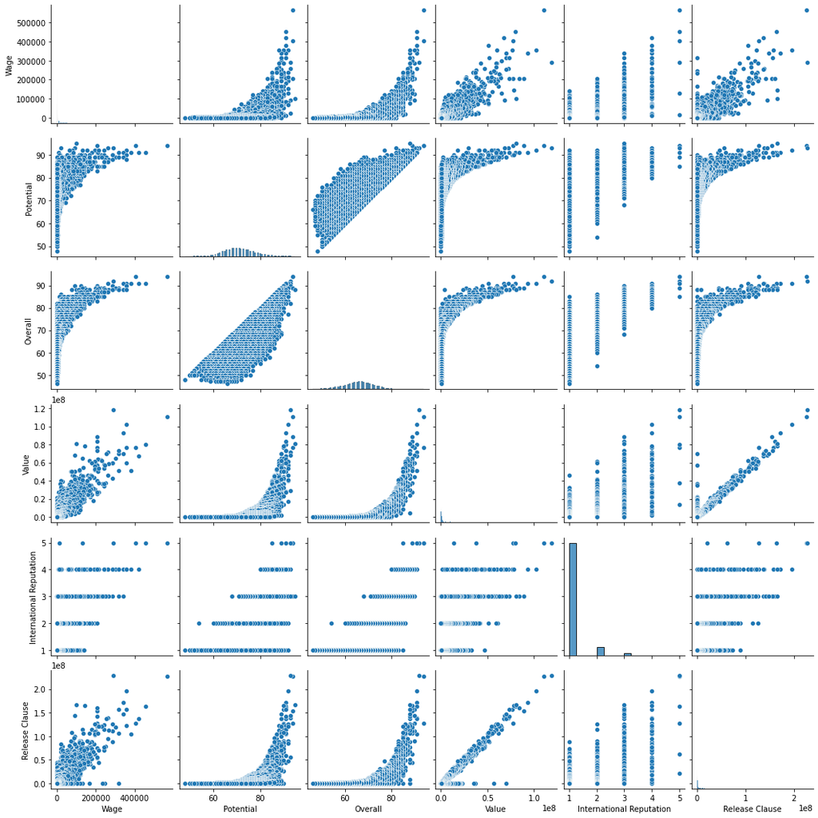

```python
sns.pairplot(df[columns])
plt.show()
```

#### As seen from the Heatmap and the Pairplot above the "Value" and "Release Clause" strongly contribute to the players wage.

The Value has a correlation of 0.86 to the wage and Release Clause has a correlation of 0.82.

## 18. Find the position in the pitch where the maximum number of players play and the position where the minimum number of players play? Display it using a plot.

```python
df_position = df.groupby('Position')['Position'].count().sort_values(ascending=False)
df_position
```

```
Position
ST     2152
GK     2025
CB     1778
CM     1394
LB     1322
RB     1291
RM     1124
LM     1095
CAM     958
CDM     948
RCB     662
LCB     648
LCM     395
RCM     391
LW      381
RW      370
RDM     248
LDM     243
LS      207
RS      203
RWB      87
LWB      78
CF       74
LAM      21
RAM      21
RF       16
LF       15
Name: Position, dtype: int64
```

#### Maximun number of players play at Postion 'ST' and the number of players is 2152

#### Minimun number of players play at Postion 'LF' and the number of players is 15

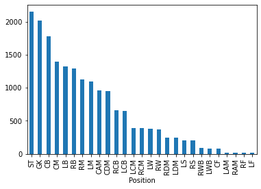

```python
df_position.plot(kind='bar')
```

## 19. How many players are from the club 'Juventus' and the wage is greater than 200K? Display all the information of such players.

```python
df_juventes = df[(df['Wage']>200000) & (df['Club']=='Juventus')]
df_juventes
```

|  | Name | Age | Nationality | Overall | Potential | Club | Value | Wage | Preferred Foot | International Reputation | ... | Composure | Marking | StandingTackle | SlidingTackle | GKDiving | GKHandling | GKKicking | GKPositioning | GKReflexes | Release Clause |
| --- | --- | --- | --- | --- | --- | --- | --- | --- | --- | --- | --- | --- | --- | --- | --- | --- | --- | --- | --- | --- | --- |
| 1 | Cristiano Ronaldo | 33 | Portugal | 94 | 94 | Juventus | 77000000.0 | 405000.0 | Right | 5.0 | ... | 95.0 | 28.0 | 31.0 | 23.0 | 7.0 | 11.0 | 15.0 | 14.0 | 11.0 | 127100000.0 |
| 15 | P. Dybala | 24 | Argentina | 89 | 94 | Juventus | 89000000.0 | 205000.0 | Left | 3.0 | ... | 84.0 | 23.0 | 20.0 | 20.0 | 5.0 | 4.0 | 4.0 | 5.0 | 8.0 | 153500000.0 |
| 24 | G. Chiellini | 33 | Italy | 89 | 89 | Juventus | 27000000.0 | 215000.0 | Left | 4.0 | ... | 84.0 | 93.0 | 93.0 | 90.0 | 3.0 | 3.0 | 2.0 | 4.0 | 3.0 | 44600000.0 |

3 rows × 55 columns

#### Only 3 players are from the club 'Juventus' whose wage is greater than 200K.

## 20. Generate a data frame containing top 5 players by Overall rating for each unique position.

```python
# Generating a dataframe of top 5 players by Overall rating for each unique position.
df_unique_position = df.groupby(by = ['Position']).apply(lambda x: x.sort_values('Overall', ascending = False).head(5))
df_unique_position
```

| Position |  | Name | Age | Nationality | Overall | Potential | Club | Value | Wage | Preferred Foot | International Reputation | ... | Composure | Marking | StandingTackle | SlidingTackle | GKDiving | GKHandling | GKKicking | GKPositioning | GKReflexes | Release Clause |
| --- | --- | --- | --- | --- | --- | --- | --- | --- | --- | --- | --- | --- | --- | --- | --- | --- | --- | --- | --- | --- | --- | --- |
| CAM | 17 | A. Griezmann | 27 | France | 89 | 90 | Atlético Madrid | 78000000.0 | 145000.0 | Left | 4.0 | ... | 87.0 | 59.0 | 47.0 | 48.0 | 14.0 | 8.0 | 14.0 | 13.0 | 14.0 | 165800000.0 |
|  | 31 | C. Eriksen | 26 | Denmark | 88 | 91 | Tottenham Hotspur | 73500000.0 | 205000.0 | Right | 3.0 | ... | 88.0 | 59.0 | 57.0 | 22.0 | 9.0 | 14.0 | 7.0 | 7.0 | 6.0 | 141500000.0 |
|  | 61 | Roberto Firmino | 26 | Brazil | 86 | 87 | Liverpool | 53000000.0 | 195000.0 | Right | 3.0 | ... | 87.0 | 60.0 | 64.0 | 42.0 | 8.0 | 11.0 | 9.0 | 6.0 | 10.0 | 104700000.0 |
|  | 66 | T. Müller | 28 | Germany | 86 | 86 | FC Bayern München | 45000000.0 | 135000.0 | Right | 4.0 | ... | 83.0 | 44.0 | 41.0 | 44.0 | 6.0 | 7.0 | 11.0 | 14.0 | 14.0 | 74300000.0 |
|  | 74 | M. Özil | 29 | Germany | 86 | 86 | Arsenal | 43500000.0 | 190000.0 | Left | 4.0 | ... | 82.0 | 24.0 | 16.0 | 19.0 | 6.0 | 14.0 | 10.0 | 6.0 | 14.0 | 82700000.0 |
| ... | ... | ... | ... | ... | ... | ... | ... | ... | ... | ... | ... | ... | ... | ... | ... | ... | ... | ... | ... | ... | ... | ... |
| ST | 1 | Cristiano Ronaldo | 33 | Portugal | 94 | 94 | Juventus | 77000000.0 | 405000.0 | Right | 5.0 | ... | 95.0 | 28.0 | 31.0 | 23.0 | 7.0 | 11.0 | 15.0 | 14.0 | 11.0 | 127100000.0 |
|  | 10 | R. Lewandowski | 29 | Poland | 90 | 90 | FC Bayern München | 77000000.0 | 205000.0 | Right | 4.0 | ... | 86.0 | 34.0 | 42.0 | 19.0 | 15.0 | 6.0 | 12.0 | 8.0 | 10.0 | 127100000.0 |
|  | 16 | H. Kane | 24 | England | 89 | 91 | Tottenham Hotspur | 83500000.0 | 205000.0 | Right | 3.0 | ... | 89.0 | 56.0 | 36.0 | 38.0 | 8.0 | 10.0 | 11.0 | 14.0 | 11.0 | 160700000.0 |
|  | 23 | S. Agüero | 30 | Argentina | 89 | 89 | Manchester City | 64500000.0 | 300000.0 | Right | 4.0 | ... | 90.0 | 30.0 | 20.0 | 12.0 | 13.0 | 15.0 | 6.0 | 11.0 | 14.0 | 119300000.0 |
|  | 36 | G. Bale | 28 | Wales | 88 | 88 | Real Madrid | 60000000.0 | 355000.0 | Left | 4.0 | ... | 86.0 | 54.0 | 55.0 | 52.0 | 15.0 | 15.0 | 11.0 | 5.0 | 6.0 | 123000000.0 |

135 rows × 55 columns

```python
# Calculating the average wage for the top 5 players in every position.
df_unique_position['Wage'].groupby('Position').mean()
```

```
Position
CAM    174000.0
CB     139600.0
CDM    217000.0
CF      47400.0
CM     130600.0
GK     192800.0
LAM     81600.0
LB     177200.0
LCB    162000.0
LCM    184400.0
LDM    126600.0
LF     121200.0
LM     164600.0
LS     130200.0
LW     261000.0
LWB     34200.0
RAM     45400.0
RB     155400.0
RCB    231000.0
RCM    240800.0
RDM    105000.0
RF     148000.0
RM     131400.0
RS     132200.0
RW     202000.0
RWB     44200.0
ST     294000.0
Name: Wage, dtype: float64
```